# Modelos Bayesianos de contagem com detecção imperfeita

Competição entre Arcella e Pyxidicula

# Single-species experiments

## Modelo

Usei o modelo de (Hostetler and Chandler 2015). A ideia deste tipo de modelo de contagem com detecção imperfeita é que os valores observados (no caso número de células) é resultado de dois processos: a dinâmica do sistema (no caso representada por uma logística) e os processos de amostragem que geram a contagem. A seguir descrevo cada um destes componentes do modelo

### Nível da dinâmica do sistema

A cada passo de tempo o tamanho esperado da população é dado por uma logística a tempo discreto:

$$E[N_{t+1}] = N_t + (rN_t (1 - \frac{N_t}{K}))\Delta t$$

Onde $E[N_{t+1}]$ é o tamanho esperado (ou média) da população no tempo $t+1$, $N_t$ o tamanho no tempo anterior, $r$ a taxa de crescimento intrínseco, $K$ a capacidade de suporte (me número de indivíduos) e $\Delta t$ o tamanho do intervalo de tempo entre $t$ e $t+1$ em dias (que deve ser pequeno para este modelo aproximar bem um processo contínuo.

Para representar fontes de variação estocástica na dinâmica populacional, o tamanho da população no tempo $t+1$ segue uma distribuição Poisson, com média $E[N_{t+1}]$. Isso equivale a dizer que a cada passo de tempo o valor efetivo da população é sorteado de uma distribuição Poisson cuja média é o valor esperado pela logística.

### Nível da amostragem

A contagem de células é uma amostra do total, na qual ainda é possível detectar apenas parte delas. Supondo que as regiões da placa que são inspecionadas são uma amostra ao acaso da população (já que a cultura e homogeneizada antes das contagens), o número de células na área amostrada segue uma distribuição Poisson, cuja média é

$$E[n_t] = \frac{N_t}{A}{a}$$

Onde $n_t$ é o número de células na amostra, $A$ é a área total da cultura e $a$ a área amostrada. Este valor é apenas a densidade de células multiplicado pela área observada.

Deste total, uma proporção $p$ é detectada. Se estas detecções são eventos independentes o número de células observado em cada amostra segue uma distribuição binomial, com probabilidade de sucesso (detectabilidade) $p$ e número de tentativas $n_t$. Sob esta premissa, cada célula na área amostrada tem probabilidade $p$ de ser detectada e $1-p$ de não ser, e a média de células detectadas é $p n_t$.

### Ajuste

Fiz um ajuste Bayesiano deste modelo para cada experimento, usando MCMC, implementado na linguagem [JAGS](http://www.uvm.edu/~bbeckage/Teaching/DataAnalysis/Manuals/manual.jags.pdf), com os pacotes rjags e R2jags, do R. O código em jags do modelo está no arquivo logistic2.jag, no diretório *cluster*.

#### Priors

Usei distribuições a priori em geral pouco informativas, que foram:

- $r$ : lognormal com parâmetros $\mu=-2$, $\sigma=2$
- $K$ : uniforme entre $10$ e $100$ bilhões
- $p$: uniforme entre $0.9$ e $1$

Para definir as distribuições a priori das capacidade de suporte considerei o seguinte para definir um valor máximo:

- *Arcella* tem diâmetro de 57 micrômetros, o que dá uma área de 2551.76 micrômetros quadrados. Assim, um chute para densidade máxima é que em $1 cm^2$ haveria 39.1887 mil indivíduos. A área do frasco de cultura é 22.5 cm2, o que poderia ser completamente coberto por cerca de 0.88 milhões de células.
- *Pyxidicula* tem diâmetro de 5.3 micrômetros, o que dá uma área de 22.06 $\mu^2$. Assim, um chute para densidade máxima é que em 1 $cm^2$ haveria 4.53 milhões de indivíduos. Assim a área do frasco de cultura poderia ser coberto por cerca de 101.99 milhões de células.

## Resultados

Os ajustes demoram e foram feitos no cluster. Os códigos e os arquivos binários do R com resultados destes ajustes estão no diretório */home/paulo/lotka_volterra_tecamebas* do cluster Abacus (são muito grandes para ficar no GitHub). Os comandos abaixo carregam os binários com os resultados dos ajustes. Para funcionar vc tem que copiar os arquivos RData que estão no Abacus para um diretório *cluster* em seu diretório de trabalho do R

```r
load("cluster/arc1.RData")
load("cluster/arc2.RData")
load("cluster/arc3.RData")
load("cluster/pyx1.RData")
load("cluster/pyx2.RData")
load("cluster/pyx3.RData")
load("cluster/compfit1.RData")
load("cluster/compfit2.RData")
load("cluster/compfit3.RData")
load("cluster/compfit4.RData")
load("cluster/compfit5.RData")
load("cluster/compfit6.RData")
load("cluster/compfit7.RData")
```

### Observados e previstos

A figura abaixo mostra os números de células nas amostras a cada tempo e o intervalo de Bayesiano a 95% de probabilidade.

Nos experimentos 1 e 2 o número de células de *Pyxidicula* dá um pulo entre seis e sete dias, e depois cai. Isso pode ser assinatura de crescimento populacional muito rápido e/ou com *time delay*, que pode levar a dinâmicas que oscilam ou mesmo caos. Como o modelo logístico não tem estes componentes, não foi capaz de prever este comportamento. O valor de $K$ estimado nestes casos está próximo do valor em que a população parece estabilizar após 7 dias.  
Para *Arcella* o modelo logístico deu bons ajustes.

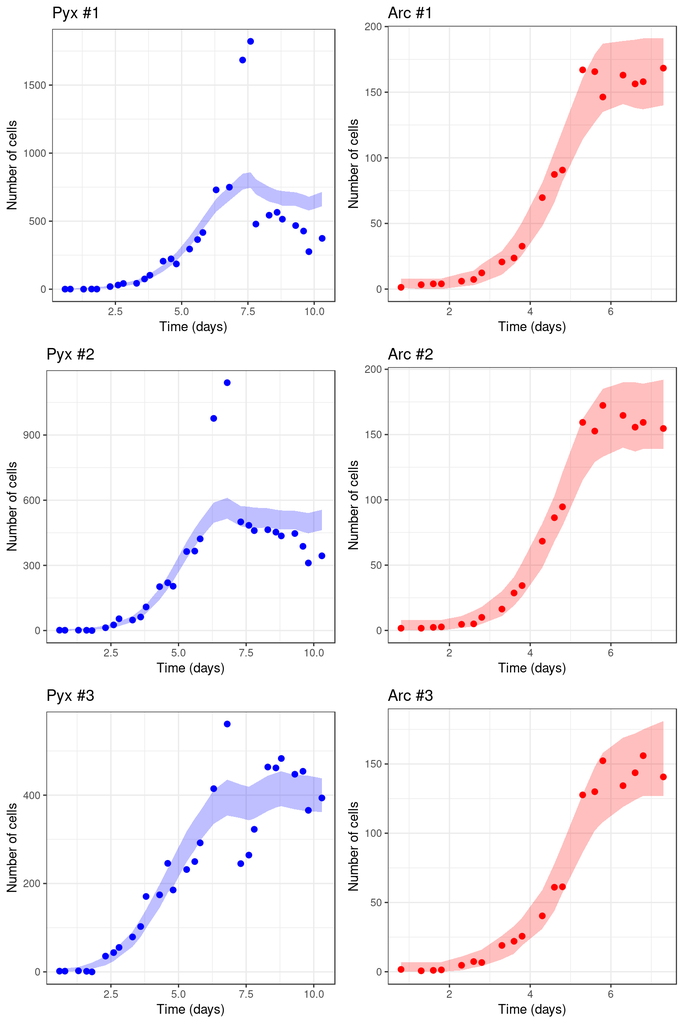

### Distribuições posteriores

Abaixo a distribuições posteriores dos parâmetros dos modelos. Os valores de $K$ estão em $cm^{-2}$. O que me chamou a atenção:

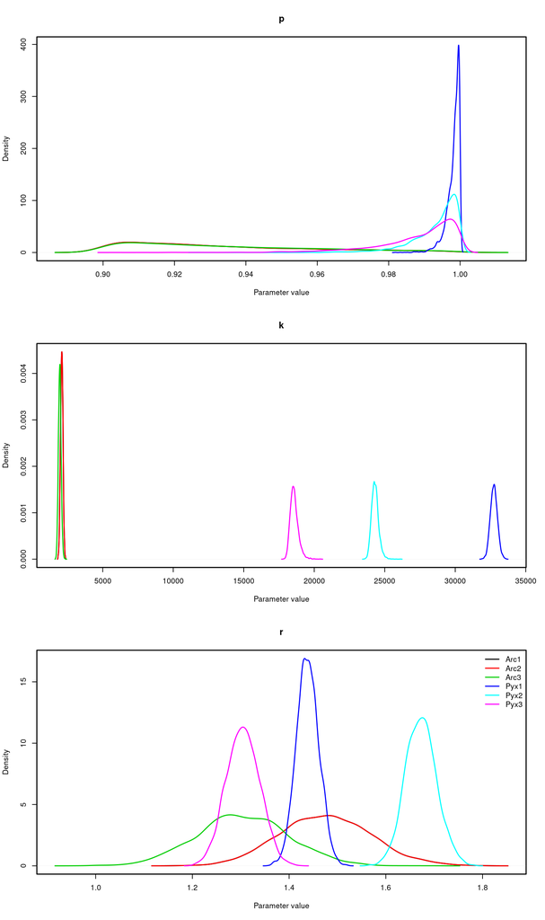

# Experimentos de competição

## Modelo

O mesmo que para a logística, com a diferença que o tamanho esperado de cada população é dado pela equação de Lotka-Volterra:

$$E[A_{t+1}] = A_t + (r_1A_t (1 - \frac{A_t+\alpha P_t}{K_1}))\Delta t$$

$$E[P_{t+1}] = P_t + (r_2P_t (1 - \frac{P_t+\beta P_t}{K_2}))\Delta t$$

Onde $A$ e $P$ são os tamanhos populacionais de *Arcella* e *Pyxidicula*, e $\alpha$ e $\beta$ os coeficientes de competição interespecífica.

## Ajuste

Da mesma maneira. O código do modelo em jags está no arquivo competition.jag, no diretório *cluster*.

#### Priors

Para os parâmetros $r$ e $K$ tentei usar como priors as distribuições posteriores dos ajustes logísticos, combinadas. A lognormal foi um bom modelo para descrever as distribuições de $r$. E assim usei como priors as lognormais ajustadas às distribuições dos valores posteriores de $r$ dos três experimentos juntos. Para os valores de $K$ tentei a mesma abordagem mas os valores de $K$ ajustados foram absurdamente altos. Por isto optei por uma distribuição uniforme, que fixa um valor máximo. Usei uniformes no intervalo e 1000 a 35000, que parecia mais plausível pelas posteriores de $K$. Para os coeficientes de competição usei lognormais com média correspondente á razão de tamanhos das duas espécies e variâncias muito grandes, para torná-las pouco informativas.

## Modelos

### Observado e previsto em cada experimento

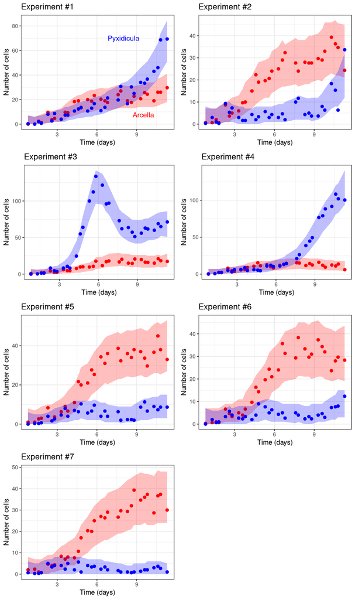

### Distribuições posteriores dos parâmetros

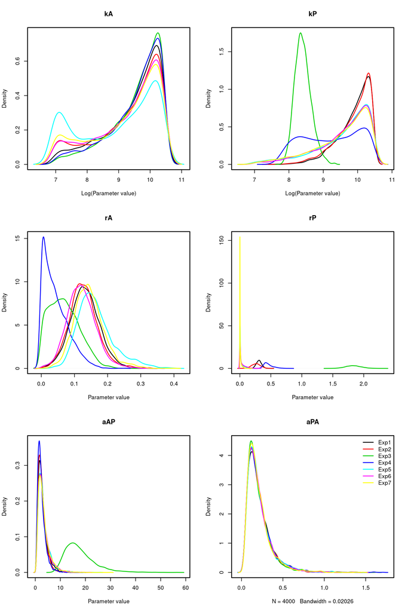

# Uma hipótese de jogo evolutivo

Em reunião 19/03/2018 Pan propôs a hipótese de que quando juntas as duas espécies teriam probabilidades altas de se extinguir se mantivessem suas taxas de crescimento intrínseco originais (observadas nas culturas puras). Assim, reduzir a reprodução seria uma adaptação para não correr este risco.

Na subseções seguintes vão resultados de três previsões destas hipótese:

- A probabilidade de coexistência deve ser baixa com valores altos de $r$
- A probabilidade de coexistência deve ser mais alta com valores baixos de $r$
- Se a redução da velocidade de reprodução é uma estratégia com duas táticas ($r$ alto e baixo) a escolha da tática de $r$ baixo pelas duas espécies deve ser um estado de equilíbrio comum em um modelo de jogos.

## Probabilidades de coexistência com valores de r altos

Uma previsão desta hipótese é que as extinções devem ser um resultado frequente dos modelos de competição se usarmos nestes modelos os valores de $r$ e $K$ observados nas culturas puras. Para testar isto, simulei estes modelos pelo mesmo tempo dos experimentos de competição, tomando os parâmetros das distribuições *a posteriori* obtidas com o ajuste Bayesiano da seguinte forma:

- Valores de $r$ e $K$ de cada espécie tomados das *posterioris* dos ajustes aos dados dos experimentos de cultura pura.
- Valores dos coeficientes de competição tomados das *posterioris* dos ajustes aos dados dos experimentos de competição.

Os parâmetros de cada experimento foram tomados pareados (isto é, não sorteei independentemente um valor de $r$ e de $K$ para uma espécie, e sim sorteei um par deste parâmetros da distribuição bivariada, para preservar sua eventual correlação).

Excluí dos experimentos as posteriores dos experimentos de competição 3 e 5, em que *Pyxidicula* e *Arcella* parecem ter valores de $r$ mais póximos de culturas puras. Com três experimentos de cultura pura por espécie e os cinco experimentos de competição que mantive é possível fazer 45 combinações de distribuições *a posteriori*. De cada uma destas combinações de Tomei 111 amostras.

Usei estes parâmetros sorteados para calcular os tamanhos populacionais de três maneiras:

- Pelo modelo com estocasticidade, para a duração do experimento e após 30 dias
- Pelos tamanhos populacionais no equilíbrio do modelo determinístico
- Tamanhos populacionais pelo modelo determinístico, para a duração do experimento

A seções a seguir mostram os resultados para cada um destas simulações

### Modelo estocástico

A proporção das simulações que tiveram populações extintas e não extintas de cada espécie no tempo de um experimento foram:

Proporção de simulações do modelo de competição estocástico com valores de r altos em que a população de cada espécie chegou ao fim de 11.3 dias com tamanhos maiores que zero.

|  | N(Pyx) = 0 | N(Pyx) > 0 |
| --- | --- | --- |
| N(Arc) = 0 | 0.000 | 0.569 |
| N(Arc) > 0 | 0.001 | 0.430 |

O evento mais provável quando as duas espécies usam seus valores de $r$ originais é a persistência de *Pyxidicula* apenas, seguido pela coexistência. A co-extinção e a persistência apenas de *Arcella* têm baixas probabilidades.

#### Prolongando a simulação para 30 dias

Proporção de simulações do modelo de competição em a população de cada espécie chegou ao fim de 30 dias com tamanhos maiores que zero.

|  | N(Pyx) = 0 | N(Pyx) > 0 |
| --- | --- | --- |
| N(Arc) = 0 | 0.000 | 0.820 |
| N(Arc) > 0 | 0.004 | 0.176 |

### Modelo determinístico

Para avaliar se a estocasticidade altera o efeito, também calculei os tamanho das populações no equilíbrio segundo o modelo Lotka-Volterra determinístico.

Também simulei as dinâmicas com este modelo determinístico, no intervalo de duração do experimento

#### Solução no equilíbrio do modelo determinístico

Os tamanho populacionais no equilíbrio são do modelo Lotka-Volterra são:

$$\hat A = \frac{K_1-\alpha K_2}{1-\alpha \beta}$$

$$\hat P = \frac{K_2-\beta K_1}{1-\alpha \beta}$$

E caso ambos sejam positivos o equilíbrio será estável se

$$\frac{1}{\beta} \ < \ \frac{K_1}{K_2} \ < \ \alpha$$

Então calculei estes valores de outras 5000 combinações de parâmetros sorteadas das posteriores da mesma maneira (valores de $r$ e $K$ tomados dos experimentos monoespecíficos, demais parâmetros dos experimentos de competição). A proporção destas combinações que resultam em tamanho populacionais no equilíbrio maior que zero e que cumprem a condição de estabilidade estimam as probabilidades de persistência e extinção no equilíbrio, sob este modelo.

Proporção de cálculos do equilíbrio determinístico com $r$ altos em que a população de cada espécie tem tamanhos maiores que zero.

|  | N(Pyx) = 0 | N(Pyx) > 0 |
| --- | --- | --- |
| N(Arc) = 0 | 0.000 | 0.832 |
| N(Arc) > 0 | 0.168 | 0.000 |

Estes valores indicam que a coexistência não deve ocorrer a longo prazo, ou é pouquíssimo provável, caso as duas espécies mantivessem os valores de $K$ e $r$ observados nas culturas mono-específicas.

#### Simulação determinística até o fim do experimento

No entanto, se usamos o modelo determinístico para calcular os tamanhos populacionais até o fim do experimento, há uma probabilidade grande das duas espécies terem populações maiores que zero:

Proporção de simulações do modelo de competição com valores de $r$ alto e sem estocasticidade em que a população de cada espécie chegou ao fim do experimento (11,3 dias) com tamanhos maiores que zero.

|  | N(Pyx) = 0 | N(Pyx) > 0 |
| --- | --- | --- |
| N(Arc) = 0 | 0.000 | 0.419 |
| N(Arc) > 0 | 0.001 | 0.580 |

Isto indica que pelo modelo determinístico o período de tempo do experimento não é suficiente para se chegar ao equilíbrio determinístico. Comparando com a seção anterior, vemos que as probabilidades de coexistência pelo modelo determinístico são maiores do que com o modelo correspondente com estocasticidade.

## Probabilidades de coexistência com valores de r baixos

Fiz as mesmas simulações para o caso em os parâmetros $r$ e $K$ das duas espécies são os observados nos experimentos de competição em que claramente houve redução do $r$ (experimentos 1, 2, 4, 6 e 7).

### Modelos com estocasticidade

Com os valores de $r$ baixos a coexistência até o fim do experimento torna-se muito mais provável, mesmo com estocasticidade ambiental.

Proporção de simulações do modelo de competição estocástico com valores de r baixos em que a população de cada espécie chegou ao fim de 11.3 dias com tamanhos maiores que zero.

|  | N(Pyx) = 0 | N(Pyx) > 0 |
| --- | --- | --- |
| N(Arc) = 0 | 0.000 | 0.008 |
| N(Arc) > 0 | 0.013 | 0.979 |

#### Prolongando para 30 dias

Proporção de simulações do modelo de competição estocástico com valores de r baixos em que a população de cada espécie chegou ao fim de 30 dias com tamanhos maiores que zero.

|  | N(Pyx) = 0 | N(Pyx) > 0 |
| --- | --- | --- |
| N(Arc) = 0 | 0.000 | 0.010 |
| N(Arc) > 0 | 0.016 | 0.973 |

### Modelo determinístico

#### Probabilidade de persistência no equilíbrio determinístico

Mesmo usando o equilíbrio determinístico, a probabilidade de coexistência é maior que zero, embora ainda muito baixa.

Proporção de cálculos do equilíbrio determinístico com $r$ baixos em que a população de cada espécie tem tamanhos maiores que zero.

|  | N(Pyx) = 0 | N(Pyx) > 0 |
| --- | --- | --- |
| N(Arc) = 0 | 0.000 | 0.731 |
| N(Arc) > 0 | 0.261 | 0.008 |

#### Simulação até o fim do experimento

Se usamos os valores baixos de $r$ sem estocasticidade há 100% de probabilidade de coexistência no intervalo de tempo do experimento:

Proporção de simulações do modelo de competição sem estocasticidade com valores de r baixos em que a população de cada espécie chegou ao fim de 11.3 dias com tamanhos maiores que zero.

|  | N(Pyx) = 0 | N(Pyx) > 0 |
| --- | --- | --- |
| N(Arc) = 0 | 0 | 0 |
| N(Arc) > 0 | 0 | 1 |

## Probabilidades de persistência para LH e HL

Resultados para modelo com estocasticidade, pela duração do experimento

### Arcella com r alto e Pyxidiculla com r baixo

Proporção de simulações do modelo de competição estocástico com valores de r altos para *Arcella* e baixos para *Pixydiculla* em que a população de cada espécie chegou ao fim de 11.3 dias com tamanhos maiores que zero.

|  | N(Pyx) = 0 | N(Pyx) > 0 |
| --- | --- | --- |
| N(Arc) = 0 | 0.000 | 0.000 |
| N(Arc) > 0 | 0.021 | 0.979 |

### Pyxidiculla com r alto e Arcella com r baixo

Proporção de simulações do modelo de competição estocástico com valores de r altos para *Pixydiculla* e baixos para *Arcella* em que a população de cada espécie chegou ao fim de 11.3 dias com tamanhos maiores que zero.

|  | N(Pyx) = 0 | N(Pyx) > 0 |
| --- | --- | --- |
| N(Arc) = 0 | 0 | 0.041 |
| N(Arc) > 0 | 0 | 0.959 |

## Equilíbrios em um jogo com duas estratégias

Vamos supor que cada espécie tem a tática de manter $r$ alto ou baixo, e que fazem isto em reação ao que a outra está fazendo. Neste cenário simples podemos aplicar [teoria de jogos básica](https://en.wikipedia.org/wiki/Normal-form_game) e montar as matrizes de *payoff* para cada espécie, que expressam o ganho de cada estratégia possível, para cada espécie.

Para fazer isto, rodei as mesmas simulações de Lotka-Volterra, mas sorteando os parâmetros das *posterioris* para corresponder a cada uma das situações. Por exemplo, para simular uma situação em que *Arcella* mantém o $r$ alto mas não *Pyxidicula*, sorteei os valores de $r$ e $k$ das *posterioris* dos experimentos de cultura pura de *Arcella*, mas os demais parâmetros das *posterioris* dos experimentos de competição. Para simular a situação em que apenas *Pyxidicula* mantém o $r$ alto fiz o contrário. Antes de detalhar estes procedimentos vai uma explicação de como analisei as matrizes de *payoff* obtidas assim.

### Critérios de equilíbrio

#### Equilíbrio de Nash

As tabelas de *payoff* mostram o ganho para cada espécie em cada combinação de estratégias. Este ganho pode ser por exemplo a probabilidade de persistência ou o tamanho da população após um certo tempo. A seguir um exemplo destas matrizes:

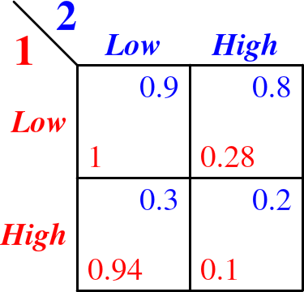

Exemplo de matrizes de payoff para dois jogadores cada um com duas estratégias

Nesta tabela os valores de payoff para *Arcella* (vermelho) na primeira linha são maiores que os valores na segunda linha, em cada coluna. Isto quer dizer que para esta combinação de parâmetros a estratégia mais vantajosa para *Arcella* é sempre a da primeira linha, ou seja, manter o $r$ baixo, independente da estratégia de *Pyxidicula*

Da mesma forma, os valores para *Pyxidicula* (azul) da primeira coluna de cada linha são os maiores. Ou seja, para qualquer estratégia de *Arcella* a estratégia mais vantajosa para *Pyxidicula* também é manter o $r$ baixo.

Neste caso temos um [Equilíbrio de Nash](https://en.wikipedia.org/wiki/Nash_equilibrium), com as duas espécies em estratégia de manter baixos crescimentos populacionais.

#### Equilíbrio geral

Há condições de equilíbrio de estratégias menos estritas que as de Nash, porque mesmo sem esta condição é possível que uma ou mais estratégias sejam estáveis. Por exemplo, para as matrizes a seguir há dois equilíbrios, definidos como combinações de estratégias em que nenhuma das duas espécies consegue aumentar seu *payoff* se mudar de estratégia, se a outra espécie não mudar:

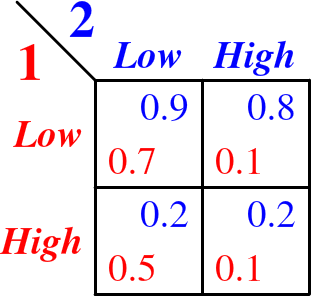

Matrizes de payoff com dois equilíbrios

Os equilíbrios são ambas as espécies com baixo $r$ (Low/Low) ou ambas com $r$ alto (High/High). Note que nestes dois casos a mudança de estratégia leva a um benefício igual ou menor.

## Probabilidades de equilíbrio de cada estratégia

Nesta seção uso os critérios de equilíbrio definidos acima para analisar as matrizes de *payoff* obtidas com as simulações.

Chamo aqui “combinação de parâmetros” um conjunto de valores dos parâmetros tomados das posteriores dos experimentos de competição, e tomados das posteriores dos experimentos de culturas puras. Para cada combinação desta repeti a simulação 100 vezes e com isso montei duas matrizes de *payoffs*:

- Probabilidade de persistência: proporção das 100 réplicas de simulações com os mesmos parâmetros em que cada espécie tinha população maior que zero ao fim da simulação.
- Tamanho populacional médio: média dos tamanhos populacionais nas 100 réplicas ao fim de cada simulação.

Simulei 100 combinações de parâmetros para cada uma das 45 combinações possíveis das 5 posteriores dos experimentos de competição com as 3 posteriores de cada experimento de cultura pura.

As simulações correram até o tempo que duraram os experimentos de competição ( 11.3 dias), usando os intervalos reais de medição, que variaram entre 0.2 e 0.8 dias.

Em resumo, para cada combinação de parâmetros obtive então uma matriz de *payoffs* de persistência e outra de tamanho populacional. Verifiquei em cada uma destas matrizes quais eram as combinações em equilíbrio de Nash e em equilíbrio senso geral, como defini acima. As proporções das matrizes em que cada estratégia cumpriu os requisitos de um destes equilíbrios estimam as probabilidades posteriores destes equilíbrios, ou seja a probabilidade posterior de que cada combinação de estratégias seja estável.

Abaixo tabela com estas probabilidades para *payoffs* baseados na probabilidade de persistência

### Para a duração do experimento

Posterior probabilities of Nash equilibrium for each combination of strategies. Probabilities calculated from simulations of the competition dynamics ran till 11.3 days. Payoff: probability of population persistence at the end of simulations.

|  | LL | LH | HL | HH |
| --- | --- | --- | --- | --- |
| Equilíbrio de Nash | 0.190 | 0.393 | 0.192 | 0.354 |
| Equilíbrio geral | 0.434 | 0.785 | 0.197 | 0.354 |

### Para 30 dias

Posterior probabilities of Nash equilibrium for each combination of strategies. Probabilities calculated from simulations of the competition dynamics ran till 30 days. Payoff: probability of population persistence at the end of simulations.

|  | LL | LH | HL | HH |
| --- | --- | --- | --- | --- |
| Equilíbrio de Nash | 0.222 | 0.360 | 0.073 | 0.188 |
| Equilíbrio geral | 0.398 | 0.867 | 0.076 | 0.207 |

# Pontos a discutir

# References

Hostetler, Jeffrey A, and Richard B Chandler. 2015. “Improved State-Space Models for Inference About Spatial and Temporal Variation in Abundance from Count Data.” *Ecology* 96 (6). Wiley Online Library: 1713–23.

Paulo Inácio Prado

19 de junho de 2018